# Homework 6

Stat 452

Author

Alicie Isa

For this assignment, I want you to work together with a partner.

## Research Question

1. Based on your previous work with this data set, including your literature search, come up with one research question to address as a team.

ANSWER: After accounting for baseline age, do memory scores change differently over time between the memory training group and the control group?

2. Based on your previous work with this data set, including your literature search, come up with a mean model (x’s and their functional format) that addresses your research question (accounting for potential confounders).

ANSWER (In R formula structure):

```r
library(tidyverse)

source("cleaning_active.R")
memory_data <- activeLong %>%
  filter(INTGRP %in% c("Memory Training", "Control")) %>%
  droplevels() %>%
  mutate(INTGRP = relevel(INTGRP, ref = "Control"))

Memory ~ factor(Years) * INTGRP + AgeAtBaseline
```

```
Memory ~ factor(Years) * INTGRP + AgeAtBaseline
```

## Longitudinal Models

Let’s do a quick review:

**Marginal Models** For models fit with GEE, we need to specify a working correlation structure, but the robust standard errors are valid even if we get that structure wrong.

**Mixed Effects Models** We can write a linear mixed effects model in terms of our outcome vector,

$$\mathbf{Y}_{i} = \mathbf{X}_{i}\boldsymbol\beta + \mathbf{Z}_i\mathbf{b}_i + \boldsymbol\epsilon_i$$

$$= \text{Fixed effects} + \text{Random effects} + \text{Error}$$

where $\mathbf{X}_i$ is the design matrix for the fixed effects, $\mathbf{Z}_i$ is the design matrix for the random effects (a subset of columns of $\mathbf{X}_i$), $\boldsymbol\epsilon_i\sim N(0,\boldsymbol\Sigma)$, $\mathbf{b}_i\sim N(0,\mathbf{G})$, and $\mathbf{b}_i$ and $\boldsymbol\epsilon_i$ are independent.

Thus,

$$\mathbf{Y}_{i}\sim \mathcal{N}(\mathbf{X}_{i}\boldsymbol\beta,\mathbf{Z}_i\mathbf{G}\mathbf{Z}_i^T + \boldsymbol\Sigma)$$

BEFORE YOU BEGIN: Decide whether you and your partner want to use Mixed Effects or GEE models. You’ll use the type of model throughout.

3. Come up with at least 2 candidate models (different correlation structures) that you want to fit.
- GEE: consider working correlation structures, describe them in words, and then fit them with `geeM::geem()`.
- Mixed Effects: start with random intercept and consider which coef could be random, describe them in words, and then fit them with `lme4::lmer()`.

```r
#source('cleaning_active.R') # Open Cleaning.R to see the data cleaning steps to create a long format dataset
library(geeM)
#library(lme4)
library(tidyr)

memory_data <- memory_data %>%
  drop_na(Memory, Years, INTGRP, AgeAtBaseline) %>%
  arrange(AID, Years)
```

ANSWER:

- Model 1:The first model uses an independence working correlation structure, which assumes that memory scores from different measurements of the same participant are uncorrelated. Although this assumption may not hold, we can use it to compare with the second model. We will use robust standard errors to account for within-participant correlation even if this working correlation assumption is wrong.

```r
gee_mod1 <- memory_data %>%
  geem(Memory ~ factor(Years) * INTGRP + AgeAtBaseline, data = ., id = AID, corstr = "independence")

summary(gee_mod1)
```

```
                                        Estimates Model SE Robust SE     wald
(Intercept)                               162.100  2.63100   5.17600  31.3200
factor(Years)0.25                          -1.915  0.91310   0.47520  -4.0300
factor(Years)1                             -2.482  0.96400   0.54390  -4.5640
factor(Years)2                              2.068  0.98230   0.63940   3.2340
factor(Years)3                              3.200  1.00800   0.65290   4.9010
factor(Years)5                             -5.035  1.05900   0.82380  -6.1120
factor(Years)10                            -9.917  1.30100   1.11700  -8.8790
INTGRPMemory Training                       1.150  0.91380   0.86070   1.3370
AgeAtBaseline                              -1.117  0.03452   0.06981 -16.0000
factor(Years)0.25:INTGRPMemory Training     2.506  1.29100   0.68820   3.6420
factor(Years)1:INTGRPMemory Training        2.624  1.35900   0.77770   3.3750
factor(Years)2:INTGRPMemory Training        2.601  1.38100   0.88280   2.9470
factor(Years)3:INTGRPMemory Training        2.583  1.41400   0.91970   2.8080
factor(Years)5:INTGRPMemory Training        3.295  1.49000   1.18400   2.7830
factor(Years)10:INTGRPMemory Training       0.559  1.81500   1.64600   0.3397
                                                p
(Intercept)                             0.000e+00
factor(Years)0.25                       5.586e-05
factor(Years)1                          5.020e-06
factor(Years)2                          1.222e-03
factor(Years)3                          9.600e-07
factor(Years)5                          0.000e+00
factor(Years)10                         0.000e+00
INTGRPMemory Training                   1.813e-01
AgeAtBaseline                           0.000e+00
factor(Years)0.25:INTGRPMemory Training 2.707e-04
factor(Years)1:INTGRPMemory Training    7.391e-04
factor(Years)2:INTGRPMemory Training    3.212e-03
factor(Years)3:INTGRPMemory Training    4.977e-03
factor(Years)5:INTGRPMemory Training    5.389e-03
factor(Years)10:INTGRPMemory Training   7.341e-01

 Estimated Correlation Parameter:  0
 Correlation Structure:  independence
 Est. Scale Parameter:  259.3

 Number of GEE iterations: 2
 Number of Clusters:  1391    Maximum Cluster Size:  7
 Number of observations with nonzero weight:  6547
```

- Model 2:We chose exchangeable as the working correlation structure for the second model. Although we haven’t covered it in class, we think it is worth considering because memory scores from the same participant may be correlated. This structure assumes the same correlation between any two measurements from the same participant, no matter how far apart the measurements are.

```r
gee_mod2 <- memory_data %>%
  geem(Memory ~ factor(Years) * INTGRP + AgeAtBaseline, data = ., id = AID, corstr = "exchangeable")

summary(gee_mod2)
```

```
                                        Estimates Model SE Robust SE     wald
(Intercept)                              169.1000  4.97300   5.05200  33.4600
factor(Years)0.25                         -2.4220  0.44630   0.39020  -6.2070
factor(Years)1                            -3.8600  0.47810   0.42650  -9.0500
factor(Years)2                             0.3978  0.48940   0.48550   0.8193
factor(Years)3                             1.2780  0.50310   0.45760   2.7940
factor(Years)5                            -8.5460  0.53060   0.61670 -13.8600
factor(Years)10                          -16.0600  0.65650   0.83800 -19.1700
INTGRPMemory Training                      0.7688  0.88870   0.83930   0.9161
AgeAtBaseline                             -1.2120  0.06665   0.06816 -17.7800
factor(Years)0.25:INTGRPMemory Training    2.9300  0.63150   0.55230   5.3050
factor(Years)1:INTGRPMemory Training       2.7050  0.67340   0.57560   4.6990
factor(Years)2:INTGRPMemory Training       2.7480  0.68680   0.63770   4.3090
factor(Years)3:INTGRPMemory Training       2.6580  0.70450   0.63670   4.1740
factor(Years)5:INTGRPMemory Training       3.8880  0.74650   0.85580   4.5430
factor(Years)10:INTGRPMemory Training      0.1487  0.91790   1.19700   0.1242
                                                p
(Intercept)                             0.000e+00
factor(Years)0.25                       0.000e+00
factor(Years)1                          0.000e+00
factor(Years)2                          4.126e-01
factor(Years)3                          5.211e-03
factor(Years)5                          0.000e+00
factor(Years)10                         0.000e+00
INTGRPMemory Training                   3.596e-01
AgeAtBaseline                           0.000e+00
factor(Years)0.25:INTGRPMemory Training 1.100e-07
factor(Years)1:INTGRPMemory Training    2.610e-06
factor(Years)2:INTGRPMemory Training    1.639e-05
factor(Years)3:INTGRPMemory Training    2.993e-05
factor(Years)5:INTGRPMemory Training    5.540e-06
factor(Years)10:INTGRPMemory Training   9.011e-01

 Estimated Correlation Parameter:  0.7779
 Correlation Structure:  exchangeable
 Est. Scale Parameter:  265

 Number of GEE iterations: 5
 Number of Clusters:  1391    Maximum Cluster Size:  7
 Number of observations with nonzero weight:  6547
```

4. Write bullet points about what you learn about your outcome, research question, and the modeling process from fitting these two models.

ANSWER:

-Both models show that participants who were older at baseline had lower average memory scores. The baseline age coefficient ranges from about −1.1 to −1.2 across the two models, meaning that each additional year of baseline age is associated with a 1.1- to 1.2-point lower average memory score, when holding treatment group and follow-up year constant. -After accounting for baseline age, both models show that the memory training group had greater increases from baseline at years 2 and 3 and smaller declines at year 5 than the control group. For example, in the exchangeable model, the control group’s estimated average score at year 5 is 8.55 points below baseline, while the memory training group’s score is 4.66 points below its own baseline. But by year 10, the interaction coefficients are close to zero in both models, suggesting that the memory training group no longer shows a noticeably smaller decline from baseline than the control group. -The exchangeable model shows a within-participant correlation of about 0.78, suggesting that the memory scores from the same person are strongly correlated after accounting for the predictors. Its Model SE and Robust SE are generally closer than those in the independence model. Although the two models give similar results about baseline age and the training-related differences in change, the year 5 and year 10 coefficients differ more obviously. The year 5 coefficient is −5.04 in the independence model whereas −8.55 in the exchangeable model, and the year 10 coefficient is respectively −9.92 and −16.06. This shows that the choice of working correlation structure can affect both the estimates and their standard errors.

## Inference

### Hypothesis Testing for Fixed Coefficients (one at a time)

We can use this inference tool for either GEE or Mixed Effects Models.

We can test whether $\beta_k=0$ for some $k$.

In marginal models (GEE), the estimated covariance matrix for $\hat{\boldsymbol\beta}$ is given by the robust sandwich estimator. The Robust SE for $\hat{\beta}_k$ is the square rooted values of the diagonal of this matrix corresponding to $\hat{\beta}_k$. This is what is reported in the summary output as Robust SE.

In mixed effects models, the estimated covariance matrix for $\hat{\boldsymbol\beta}$ is based on assuming the random effects are correct.

To test the hypothesis $H_0: \beta_k=0$ vs. $H_A: \beta_k\not=0$, we can calculate a z-statistic,

$$z = \frac{\hat{\beta}_k}{SE(\hat{\beta}_k)}$$

With GEE, the `geem()` function provides z statistics (labeled as `wald`) and associated p-values for testing $H_0: \beta_k= 0$. These p-values come from a Normal distribution because we know that is the asymptotic (as the sample size, $n\rightarrow \infty$) distribution for these estimates.

With mixed effects, the `lmer()` function provides z statistics (labeled as `t-value`) for the fixed effects (but not the p-values) for testing $H_0: \beta_k= 0$. We could compare the t-values to the cut off of +/-2 because we know that the asymptotic (as the sample size, $n\rightarrow \infty$) distribution for these estimates is Normal if the model is correct.

```r
#gee_mod1 %>% summary()
#lmer_mod1 %>% summary()
```

5. Looking back on the models you fit, what do you conclude about the fixed coefficients? Do you think they are zero or not?

ANSWER:

Using the Robust SEs and a 0.05 cutoff, both models mostly agree, so the numbers below are from the exchangeable model. - The baseline age coefficient is not zero (-1.21, p < 0.001). - The treatment group coefficient could be zero (0.77, p = 0.36), so the two groups started out similar. - Most of the follow-up year coefficients are not zero. Year 2 is the exception (0.40, p = 0.41). - The interaction coefficients are not zero from 0.25 to 5 years (2.66 to 3.89, all p < 0.001), but the year 10 interaction could be zero (0.15, p = 0.90).

### Diagnostics

For any model with a quantitative outcome, we should check to see if the residuals have no pattern.

6. Create a residual plot for your best model so far, plotting the residuals on the y-axis against a quantitative x-variable. Comment on the residual plot. See some example code below.

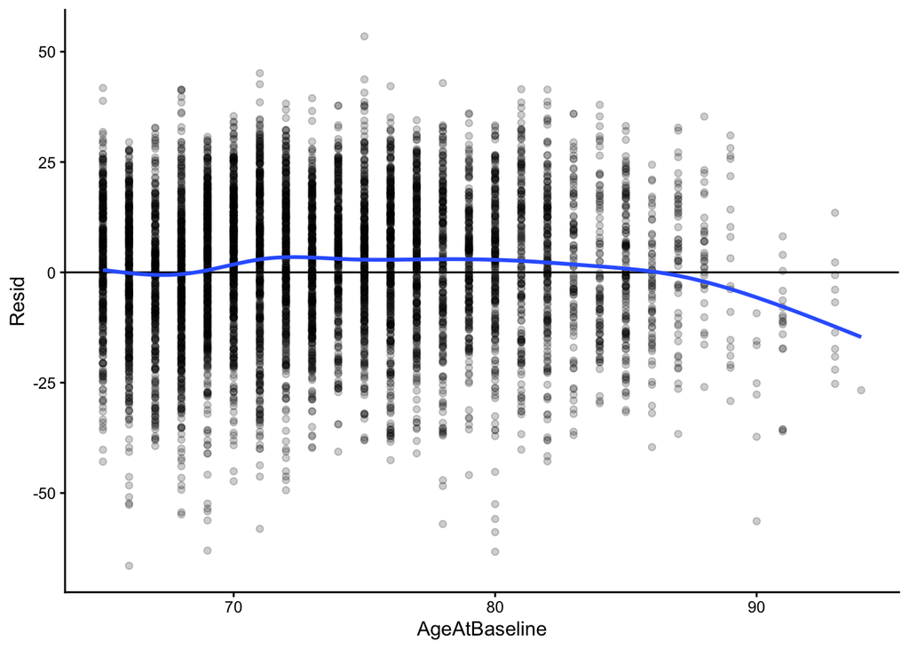

```r
# Residuals = Obs - Predicted
data <- memory_data %>% mutate(y = Memory)

data %>%
  mutate(Pred = predict(gee_mod2)) %>%  #replace mod with your chosen model
  mutate(Resid = y - Pred) %>% #replace y with your outcome
  ggplot(aes(x = AgeAtBaseline, y = Resid)) +   # you can replace Pred with a quantitative x
  geom_point(alpha = .2) +
  geom_hline(yintercept = 0) +
  geom_smooth(se = FALSE) +
  theme_classic()
```

7. Considering all of the choices you need to make, make an argument for one final model using a variety of tools in 3-5 sentences.

ANSWER:  
We picked the exchangeable model (Model 2) as our final model. Memory scores from the same person are strongly correlated (about 0.78), so the independence assumption doesn’t really make sense. The Model SEs and Robust SEs are also closer in the exchangeable model (0.067 vs. 0.068 for baseline age, compared to 0.035 vs. 0.070 in the independence model). The residual plot doesn’t show a strong pattern for most ages either. The Model SEs are still a little too small at years 5 and 10, so we use the Robust SEs for our conclusions.

8. Using that final model, what do you conclude about your original research question about brain training among the elderly?

ANSWER: After accounting for baseline age, memory scores did change differently between the two groups. From 0.25 to 5 years, the memory training group did about 3 points better than the control group compared to their own baseline. But by year 10 the difference was basically gone (0.15, p = 0.90). So memory training seems to slow memory decline for about 5 years, but it doesn’t stop it, and the benefit doesn’t seem to last 10 years. We’re also less sure about year 10 because far fewer people were still in the study by then.

## Done!

- Render your homework.
- Make sure the html file looks like you want it.
- Submit your assignment as instructed.